# Notebook

|  | [FREYA](https://www.project-freya.eu/en) WP2 [User Story 1](https://github.com/datacite/freya/issues/30) | As a data center, I want to see the citations of publications that use my repository for the underlying data, so that I can demonstrate the impact of our repository. |
| --- | --- | --- |

It is important for repositories of scientific data to monitor and report on the impact of the data they store. One useful proxy of that impact are citations of publications accompanying the deposited data.

This notebook uses the [DataCite GraphQL API](https://api.datacite.org/graphql) to retrieve data (a.k.a. works) and their citations from three different repositories: [PANGAEA](https://www.pangaea.de/), [DRYAD](https://datadryad.org/stash) and [Global Biodiversity Information Facility](https://www.gbif.org/data-repository), using *polarstern*, *butterfly* and *Lake Malawi* as example queries respectively.

**Goal**: By the end of this notebook you should be able to:

- Retrieve works for a chosen repository and query, along with associated metrics such as citation, view and download counts;
- Visualise the work counts over time, e.g.

[figure not shown]

- Present the works in a tabular format and download them in a single BibTeX file;
- For a given work, retrieve all the citations, present them in a tabular format and then download them in a single BibTeX file.

## Install libraries and prepare GraphQL client

```python
%%capture
# Install required Python packages
!pip install gql requests numpy pandas
```

```python
# Prepare the GraphQL client
import requests
from IPython.display import display, Markdown
from gql import gql, Client
from gql.transport.requests import RequestsHTTPTransport

_transport = RequestsHTTPTransport(
    url='https://api.datacite.org/graphql',
    use_json=True,
)

client = Client(
    transport=_transport,
    fetch_schema_from_transport=True,
)
```

## Define and run the GraphQL query

Define the GraphQL to find all works from PANGAEA, DRYAD and Global Biodiversity Information Facility (GBIF) repositories using keywords: *polarstern*, *butterfly* and *Lake Malawi* respectively.

```python
# Generate the GraphQL query
query_params = {
    "pangaea_repository" : "pangaea.repository",
    "pangaea_keyword" : "polarstern",
    "dryad_repository" : "dryad.dryad",
    "dryad_keyword" : "butterfly",
    "gbif_repository" : "gbif.gbif",
    "gbif_keyword" : "Lake Malawi",
}

query = gql("""query getWorksByRepositoryAndKeyword(
    $pangaea_repository: ID!, $pangaea_keyword: String!,
    $dryad_repository: ID!, $dryad_keyword: String!
    $gbif_repository: ID!, $gbif_keyword: String!
    )
{
  pangaea: repository(id: $pangaea_repository) {
    id
    name
    citationCount
    works(query: $pangaea_keyword) {
      totalCount
      published {
        title
        count
      }
      nodes {
        id
        type
        publicationYear
        bibtex
        titles {
          title
        }
        citationCount
        viewCount
        downloadCount
      }
    }
  },
  dryad: repository(id: $dryad_repository) {
    id
    name
    citationCount
    works(query: $dryad_keyword) {
      totalCount
      published {
        title
        count
      }
      nodes {
        id
        type
        publicationYear
        bibtex
        titles {
          title
        }
        citationCount
        viewCount
        downloadCount
      }
    }
  },
  gbif: repository(id: $gbif_repository) {
    id
    name
    citationCount
    works(query: $gbif_keyword) {
      totalCount
      published {
        title
        count
      }
      nodes {
        id
        type
        publicationYear
        bibtex
        titles {
          title
        }
        citationCount
        viewCount
        downloadCount
      }
    }
  }
}
""")
```

Run the above query via the GraphQL client

```python
import json
data = client.execute(query, variable_values=json.dumps(query_params))
```

## Display the number of works

For each repository, display the total number of works matching the respective query.

```python
# Get the total number of datasets matching the query
works = {}
for repo in ['pangaea', 'dryad', 'gbif']:
    works[repo] = data[repo]['works']
    print("The number of works for query '%s' in repository %s:\n%s" % (query_params['%s_keyword' % repo], data[repo]['name'], str(works[repo]['totalCount'])))
```

```
The number of works for query 'polarstern' in repository PANGAEA:
19616
The number of works for query 'butterfly' in repository DRYAD:
551
The number of works for query 'Lake Malawi' in repository Global Biodiversity Information Facility:
8264
```

## Display the number of citations of the works

```python
# Get the total number of citations per repository
for repo in ['pangaea', 'dryad', 'gbif']:
    print("The total number of citations for repository %s:\n%s" % (data[repo]['name'], str(data[repo]['citationCount'])))
```

```
The total number of citations for repository PANGAEA:
1790058
The total number of citations for repository DRYAD:
28212
The total number of citations for repository Global Biodiversity Information Facility:
13262905
```

## Plot the number of works per year

For each repository, display a bar plot showing the counts of works matching the respective query, across years.

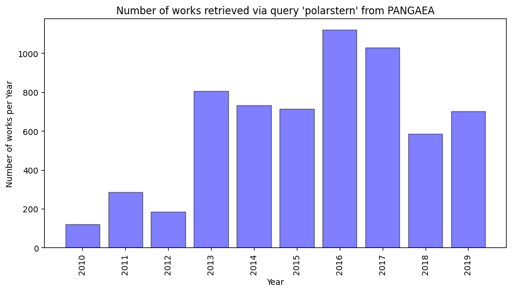

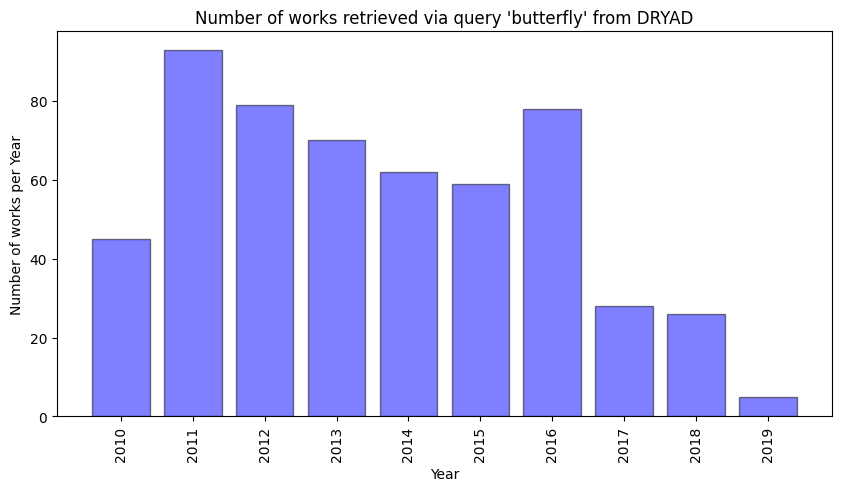

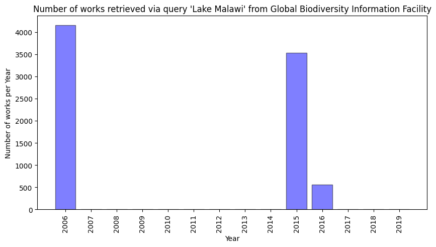

```python
# Plot the total number of datasets to date, by year
import matplotlib.pyplot as plt
from matplotlib.ticker import FormatStrFormatter
import numpy as np

for repo in ['pangaea', 'dryad','gbif']:
    works = data[repo]['works']
    name = data[repo]['name']
    plt.rcdefaults()
    sorted_years = sorted([int(s['title']) for s in works['published']])
    num_outputs4sorted_years = [s['count'] for s in works['published']]
    # Get a list of all consecutive years between min and max year (inclusive)
    all_years = list(range(sorted_years[0], sorted_years[-1]))
    # Populate output counts (into num_counts) for all consecutive years
    num_outputs = []
    for year in all_years:
        if year in sorted_years:
            idx = sorted_years.index(year)
            num_outputs.append(num_outputs4sorted_years[idx])
        else:
            num_outputs.append(0)

    fig, ax = plt.subplots(1, 1, figsize = (10, 5))
    x_pos = np.arange(len(all_years))
    ax.bar(x_pos, num_outputs, align='center', color='blue', edgecolor='black', linewidth=1, alpha=0.5)
    ax.set_xticks(x_pos)
    ax.set_xticklabels(all_years, rotation='vertical')
    ax.set_ylabel('Number of works per Year')
    ax.set_xlabel('Year')
    ax.set_title("Number of works retrieved via query '%s' from %s" % (query_params["%s_keyword" % repo], name))
    plt.show()
```

## Display works in tabular format

For each repository and query, display the works in a html table, including the number of their citations, views and downloads.

```python
from IPython.core.display import display, HTML

# Get details for each output
for repo in ['pangaea', 'dryad','gbif']:
    works = data[repo]['works']
    name = data[repo]['name']
    outputs = [['ID','Type','Publication Year','Titles','Number of Citations', 'Number of Views', 'Number of Downloads']]
    for r in works['nodes']:
        id = '<a href="%s">%s</a></html>' % (r['id'], '/'.join(r['id'].split("/")[3:]))
        titles = '; '.join([s['title'] for s in r['titles']])
        output = [id, r['type'], str(r['publicationYear']), titles, str(r['citationCount']), str(r['viewCount']), str(r['downloadCount'])]
        outputs += [output]

    # Display outputs as html table
    html_table = '<html><table><caption><b>"%s" works from %s</b></caption>' % (query_params["%s_keyword" % repo], name)
    html_table += '<tr><th style="text-align:center;">' + '</th><th style="text-align:center;">'.join(outputs[0]) + '</th></tr>'
    for row in outputs[1:]:
        html_table += '<tr><td style="text-align:left;">' + '</td><td style="text-align:left;">'.join(row) + '</td></tr>'
    html_table += '</table></html>'
    display(HTML(html_table))
```

**"polarstern" works from PANGAEA**

| ID | Type | Publication Year | Titles | Number of Citations | Number of Views | Number of Downloads |
| --- | --- | --- | --- | --- | --- | --- |
| 10.1594/pangaea.52064 | Dataset | 1997 | Radionuclides and silicate measured on water bottle samples during POLARSTERN cruise ANT-X/6, supplement to: Friedrich, Jana (1997): Polonium-210 und Blei-210 im Südpolarmeer: Natürliche Tracer für bi… | 0 | 0 | 0 |
| 10.1594/pangaea.54265 | Dataset | 1993 | Lead and aluminum in Atlantic surface water measured along the track of POLARSTERN cruise ANT-VIII/7 and ANT-IX/1 (Tables 2, 3), supplement to: Helmers, Eckard; Rutgers van der Loeff, Michiel M (1993)… | 0 | 0 | 0 |
| 10.1594/pangaea.54605 | Dataset | 1997 | Organic geochemistry on surface sediments from the Laptev Sea, supplement to: Fahl, Kirsten; Stein, Ruediger (1997): Modern organic carbon deposition in the Laptev Sea and the adjacent continental slo… | 0 | 0 | 0 |
| 10.1594/pangaea.55750 | Dataset | 2001 | Isotope tracers (Delta δ¹³C) in Weddell Sea water during POLARSTERN cruise ANT-XII/3, supplement to: Mackensen, Andreas (2001): Oxygen and carbon stable isotope tracers of Weddell Sea water masses: ne… | 0 | 0 | 0 |
| 10.1594/pangaea.56218 | Dataset | 1999 | Lipid composition of particulate matter measured on water bottle samples during POLARSTERN cruise ARK-XI/1, supplement to: Alexandrova, Olga A; Shevchenko, Vladimir P; Fahl, Kirsten; Stein, Ruediger (… | 0 | 0 | 0 |
| 10.1594/pangaea.60056 | Dataset | 2007 | Radionuclides measured in surface water samples from the South Atlantic, supplement to: Hegner, Ernst; Dauelsberg, Hans-Jürgen; Rutgers van der Loeff, Michiel M; Jeandel, Catherine; de Baar, Hein J W … | 0 | 0 | 0 |
| 10.1594/pangaea.314690 | Dataset | 2003 | Effects of varying food-availability on ecology and distribution of smallest benthic organisms in sediments of the arctic Fram Strait during POLARSTERN cruise ARK-XV/2, supplement to: Schewe, Ingo; So… | 295 | 0 | 0 |
| 10.1594/pangaea.370797 | Dataset | 2005 | Terrain model of the Håkon Mosby Mud Volcano (10 m grid size), supplement to: Beyer, Andreas; Rathlau, Rike; Schenke, Hans Werner (2005): Multibeam bathymetry of the Håkon Mosby Mud Volcano. Marine Ge… | 0 | 0 | 0 |
| 10.1594/pangaea.370808 | Dataset | 2006 | Terrain model of the eastern slope of the Porcupine Seabight (50 m grid size), supplement to: Beyer, Andreas; Schenke, Hans Werner; Klenke, Martin; Niederjasper, Fred (2003): High resolution bathymetr… | 0 | 0 | 0 |
| 10.1594/pangaea.472287 | Collection | 2006 | Standard meteorological measurements on board of POLARSTERN during expedition ANT-IV (PS08, 4 cruises, south summer 1985/86) in the Atlantic and Weddell Sea, Antarctica | 0 | 0 | 0 |
| 10.1594/pangaea.526589 | Dataset | 2006 | Digital terrain model (DTM) of the central Fram Strait, supplement to: Klenke, Martin; Schenke, Hans Werner (2002): A new bathymetric model for the central Fram Strait. Marine Geophysical Research, 23… | 0 | 0 | 0 |
| 10.1594/pangaea.526941 | Collection | 2006 | Mapping of the Eltanin impact area in the South-East Pacific | 0 | 0 | 0 |
| 10.1594/pangaea.536199 | Collection | 2006 | Clay minerals in the Norwegian Sea and Fram Strait, investigation from sediment traps and cores, supplement to: Berner, Heinrich (1991): Mechanismen der Sedimentbildung in der Framstrasse, im Arktisch… | 0 | 0 | 0 |
| 10.1594/pangaea.552177 | Collection | 1990 | Sedimentological and paleomagnetic investigations on two gravity cores and ODP sites 113-690 and 693 off Kapp Norvegia, Antarctic continental margin, supplement to: Grobe, Hannes; Fütterer, Dieter K; … | 0 | 0 | 0 |
| 10.1594/pangaea.557786 | Collection | 2006 | AWI Bathymetric Chart of the Fram Strait (BCFS) (Scale 1:100,000) | 0 | 0 | 0 |
| 10.1594/pangaea.610160 | Collection | 2007 | Polyfluorinated alkyl substances (PFAS) in high-volume air samples collected during Polarstern expedition ANT-XXIII/1, supplement to: Jahnke, Annika; Berger, Urs; Ebinghaus, Ralf; Temme, Christian (20… | 0 | 0 | 0 |
| 10.1594/pangaea.646297 | Collection | 2007 | Abundance of copepods from multinet samples during POLARSTERN cruise ANT-XXII/2 (ISPOL), supplement to: Schnack-Schiel, Sigrid B; Michels, Jan; Mizdalski, Elke; Schodlok, Michael P; Schröder, Michael … | 0 | 0 | 0 |
| 10.1594/pangaea.693818 | Collection | 1998 | Sediments in arctic sea ice - entrainment, characterization and quantification, supplement to: Lindemann, Frank (1998): Sedimente im arktischen Meereis - Eintrag, Charakterisierung und Quantifizierung… | 0 | 0 | 0 |
| 10.1594/pangaea.695350 | Collection | 2008 | Clay mineralogy of sediment cores from the Arctic Ocean, supplement to: Vogt, Christoph; Knies, Jochen (2008): Sediment dynamics in the Eurasian Arctic Ocean during the last deglaciation - The clay mi… | 0 | 0 | 0 |
| 10.1594/pangaea.701279 | Dataset | 2005 | Continuous VM-ADCP (vessel-mounted acoustic Doppler current profiler) profiles of horizontal velocities and raw acoustic gain control data during Polarstern cruise ANT-XVIII/2, supplement to: Cisewski… | 0 | 0 | 0 |
| 10.1594/pangaea.701344 | Collection | 2001 | Sedimentology and age determinations on core PS2813-1, supplement to: Holz, Christine (2001): Glazialmarine Sedimentationsprozesse am Kontinentalhang des westlichen Weddellmeeres. Diploma Thesis, Geol… | 0 | 0 | 0 |
| 10.1594/pangaea.701354 | Collection | 2008 | Heavy mineral investigations from surface sediments of the East Greenland continental margin, supplement to: Grafenauer, Ingo (1998): Terrigener Sedimenteintrag am Ostgrönländischen Kontinentalrand - … | 0 | 0 | 0 |
| 10.1594/pangaea.702107 | Collection | 2010 | Physical oceanography, sea-bed photographs and videos of benthos from the Weddell Sea taken with remote operated vehicle CHEROKEE during POLARSTERN cruise ANT-XXIII/8, supplement to: Gutt, Julian; Bar… | 0 | 0 | 0 |
| 10.1594/pangaea.706910 | Collection | 2005 | Properties of foraminifera from Denmark Strait, supplement to: Lorenz, Andrea (2005): Variability of benthic foraminifera north and south of the Denmark Strait. PhD Thesis, Mathematisch-Naturwissensch… | 0 | 0 | 0 |
| 10.1594/pangaea.708081 | Dataset | 1997 | AWI Bathymetric Chart of the Weddell Sea, Antarctica (BCWS) | 0 | 0 | 0 |

**"butterfly" works from DRYAD**

| ID | Type | Publication Year | Titles | Number of Citations | Number of Views | Number of Downloads |
| --- | --- | --- | --- | --- | --- | --- |
| 10.5061/dryad.8bb43 | Dataset | 2011 | Data from: UV photoreceptors and UV-yellow wing pigments in Heliconius butterflies allow a color signal to serve both mimicry and intraspecific communication | 1 | 145 | 43 |
| 10.5061/dryad.8bb43/1 | Dataset | 2011 | Reflectance spectra of Heliconiine butterfly yellow wing pigments | 0 | 0 | 0 |
| 10.5061/dryad.8bb43/2 | Dataset | 2011 | Appendix: Wing photomicrographs and averaged yellow reflectance spectra | 0 | 0 | 0 |
| 10.5061/dryad.rg4dc36s | Dataset | 2011 | Data from: Evidence for evolutionary change associated with the recent range expansion of the British butterfly, Polyommatus agestis, in response to climate change | 1 | 13 | 5 |
| 10.5061/dryad.1705/1 | Dataset | 2010 | Napeogenesspecies.xml | 0 | 0 | 0 |
| 10.5061/dryad.1705/4 | Dataset | 2010 | Ithomiaspecies.xml | 0 | 0 | 0 |
| 10.5061/dryad.1540 | Dataset | 2010 | Data from: Rapid microsatellite isolation from a butterfly by de novo transcriptome sequencing: performance and a comparison with AFLP-derived distances | 1 | 245 | 53 |
| 10.5061/dryad.1705 | Dataset | 2010 | Data from: Out of the Andes: patterns of diversification in clearwing butterflies | 1 | 189 | 53 |
| 10.5061/dryad.1276 | Dataset | 2010 | Data from: Allopatric origin of cryptic butterfly species that were discovered feeding on distinct host plants in sympatry | 1 | 88 | 11 |
| 10.5061/dryad.615 | Dataset | 2009 | Data from: A partitioned likelihood analysis of swallowtail butterfly phylogeny (Lepidoptera: Papilionidae) | 1 | 112 | 11 |
| 10.5061/dryad.cb6pk | Dataset | 2011 | Data from: Similarity and specialization of the larval versus adult diet of European butterflies and moths | 1 | 179 | 68 |
| 10.5061/dryad.f0b2f083 | Dataset | 2012 | Data from: Genomic regions with a history of divergent selection affect fitness of hybrids between two butterfly species | 1 | 127 | 44 |
| 10.5061/dryad.vj86fq35 | Dataset | 2012 | Data from: Response to selection on cold tolerance is constrained by inbreeding | 1 | 82 | 17 |
| 10.5061/dryad.d56g84n5 | Dataset | 2012 | Data from: Use of an exotic host plant affects mate choice in an insect herbivore | 1 | 61 | 13 |
| 10.5061/dryad.s672t4gh | Dataset | 2012 | Data from: Dispersal and gene flow in the rare, parasitic Large Blue butterfly Maculinea arion | 1 | 67 | 21 |
| 10.5061/dryad.7nn6p | Dataset | 2012 | Data from: The evolution of alternative developmental pathways: footprints of selection on life-history traits in a butterfly | 1 | 100 | 14 |
| 10.5061/dryad.82j66 | Dataset | 2012 | Data from: Food plant-derived disease tolerance and resistance in a natural butterfly-plant-parasite interaction | 1 | 80 | 23 |
| 10.5061/dryad.65r9c | Dataset | 2012 | Data from: Does selection on increased cold tolerance in the adult stage confer resistance throughout development? | 1 | 51 | 20 |
| 10.5061/dryad.m27qq | Dataset | 2012 | Data from: Butterfly genome reveals promiscuous exchange of mimicry adaptations among species | 0 | 58 | 18 |
| 10.5061/dryad.c7f1f | Dataset | 2012 | Data from: A range-wide genetic bottleneck overwhelms landscape heterogeneity and local abundance in shaping genetic patterns of an alpine butterfly (Lepidoptera: Pieridae: Colias behrii) | 1 | 59 | 17 |
| 10.5061/dryad.284gk | Dataset | 2012 | Data from: Ecological constraints on female fitness in a phytophagous insect | 1 | 64 | 19 |
| 10.5061/dryad.5rm2f | Dataset | 2012 | Data from: Environmental risk assessment for the small tortoiseshell Aglais urticae and a stacked Bt-maize with combined resistances against Lepidoptera and Chrysomelidae in central European agrarian … | 1 | 115 | 14 |
| 10.5061/dryad.f76f3 | Dataset | 2013 | Data from: Transcriptome analysis reveals novel patterning and pigmentation genes underlying Heliconius butterfly wing pattern variation | 1 | 89 | 33 |
| 10.5061/dryad.733d9 | Dataset | 2012 | Data from: Dissecting the contributions of plasticity and local adaptation to the phenology of a butterfly and its host plants | 1 | 70 | 18 |
| 10.5061/dryad.cr17v | Dataset | 2012 | Data from: Sharp genetic discontinuity across a unimodal Heliconius hybrid zone | 1 | 216 | 44 |

**"Lake Malawi" works from Global Biodiversity Information Facility**

| ID | Type | Publication Year | Titles | Number of Citations | Number of Views | Number of Downloads |
| --- | --- | --- | --- | --- | --- | --- |
| 10.15468/n6ftyd | Dataset | 2019 | rmca-albertine-rift-cichlids | 206 | 0 | 0 |
| 10.15468/dl.fk6ozu | Dataset | 2015 | GBIF Occurrence Download | 0 | 0 | 0 |
| 10.15468/dl.sdaj2e | Dataset | 2015 | GBIF Occurrence Download | 0 | 0 | 0 |
| 10.15468/dl.pyr4ax | Dataset | 2015 | GBIF Occurrence Download | 0 | 0 | 0 |
| 10.15468/dl.yj2she | Dataset | 2015 | GBIF Occurrence Download | 0 | 0 | 0 |
| 10.15468/dl.t1aupt | Dataset | 2015 | GBIF Occurrence Download | 0 | 0 | 0 |
| 10.15468/dl.iad1t6 | Dataset | 2015 | GBIF Occurrence Download | 0 | 0 | 0 |
| 10.15468/dl.fujlga | Dataset | 2015 | GBIF Occurrence Download | 0 | 0 | 0 |
| 10.15468/dl.oqdmcc | Dataset | 2015 | GBIF Occurrence Download | 0 | 0 | 0 |
| 10.15468/lvyqrq | Dataset | 2016 | Royal Museum of Central Africa - Albertian Rift Cichlids (ENBI wp13) | 0 | 0 | 0 |
| 10.15468/q3e6mn | Dataset | 2006 | Astiotrema turneri n. sp. (Digenea: Plagiorchiidae) from cichlid fishes (Cichlidae: Perciformes) of Lake Malawi, southeastern Africa | 0 | 0 | 0 |
| 10.15468/dl.xucfgy | Dataset | 2016 | GBIF Occurrence Download | 0 | 0 | 0 |
| 10.15468/x0wrhl | Dataset | 2006 | Astiotrema turneri n. sp. (Digenea: Plagiorchiidae) from cichlid fishes (Cichlidae: Perciformes) of Lake Malawi, southeastern Africa | 0 | 0 | 0 |
| 10.15468/dl.zvv38t | Dataset | 2016 | GBIF Occurrence Download | 0 | 0 | 0 |
| 10.15468/dl.shgios | Dataset | 2016 | GBIF Occurrence Download | 0 | 0 | 0 |
| 10.15468/dl.obxf4e | Dataset | 2016 | GBIF Occurrence Download | 0 | 0 | 0 |
| 10.15468/dl.pej1nt | Dataset | 2017 | GBIF Occurrence Download | 0 | 0 | 0 |
| 10.15468/dl.ezc6o3 | Dataset | 2017 | GBIF Occurrence Download | 0 | 0 | 0 |
| 10.15468/dl.pu4oky | Dataset | 2017 | GBIF Occurrence Download | 0 | 0 | 0 |
| 10.15468/dl.szsg5c | Dataset | 2017 | GBIF Occurrence Download | 0 | 0 | 0 |
| 10.15468/dl.zmysjk | Dataset | 2017 | GBIF Occurrence Download | 0 | 0 | 0 |
| 10.15468/dl.1pajgb | Dataset | 2017 | GBIF Occurrence Download | 0 | 0 | 0 |
| 10.15468/dl.gsfp2r | Dataset | 2017 | GBIF Occurrence Download | 0 | 0 | 0 |
| 10.15468/dl.jdlxgx | Dataset | 2018 | GBIF Occurrence Download | 0 | 0 | 0 |
| 10.15468/dl.govpwq | Dataset | 2018 | GBIF Occurrence Download | 0 | 0 | 0 |

## Download works in BibTeX format

Download the works in a single BibTeX file per repository

```python
import pandas as pd
from IPython.display import Javascript
from requests.utils import requote_uri

# For each repository, download a file of BibTeX entries in csv format
for repo in ['pangaea', 'dryad','gbif']:
    works = data[repo]['works']
    bibtex_data = []
    for r in works['nodes']:
        bibtex_data.append([r['bibtex']])
    df = pd.DataFrame(bibtex_data, columns = None)

    js_download = """
var csv = '%s';

var filename = '%s_%s.bib';
var blob = new Blob([csv], { type: 'application/x-bibtex;charset=utf-8;' });
if (navigator.msSaveBlob) { // IE 10+
    navigator.msSaveBlob(blob, filename);
} else {
    var link = document.createElement("a");
    if (link.download !== undefined) { // feature detection
        // Browsers that support HTML5 download attribute
        var url = URL.createObjectURL(blob);
        link.setAttribute("href", url);
        link.setAttribute("download", filename);
        link.style.visibility = 'hidden';
        document.body.appendChild(link);
        link.click();
        document.body.removeChild(link);
    }
}
""" % (df.to_csv(index=False, header=False).replace('\n','\\n').replace("\'","\\'").replace("\"","").replace("\r",""), query_params["%s_repository" % repo], requote_uri(query_params["%s_keyword" % repo]))

# display(Javascript(js_download))
```

## Define and run GraphQL query to retrieve citations for a single work

The query will retrieve citations for [IUCN Red List assessment occurrence data for freshwater species native to the Lake Malawi/Nyasa/Niassa Catchment](https://doi.org/10.15468/1z5fn8).

```python
# Generate the GraphQL query: Get citations for a specific work from the repository
citations_query_params = {
    "id" : "https://doi.org/10.15468/1z5fn8",
    "maxCitations" : 75
}

citation_query = gql("""query getCitationsByWorkId($id: ID!, $maxCitations: Int!)
{
  work(id: $id) {
    id
    titles {
      title
    }
    type
    publicationYear
    citations(first: $maxCitations) {
      totalCount
      nodes {
        id
        type
        publicationYear
        repository {
          id
          name
        }
        titles {
          title
        }
        bibtex
        citationCount
        viewCount
        downloadCount
      }
    }
  }
}
""")
```

Run the above query

```python
import json
citations = client.execute(citation_query, variable_values=json.dumps(citations_query_params))
```

## Display the number of citations

Display the number of citations of [IUCN Red List assessment occurrence data for freshwater species native to the Lake Malawi/Nyasa/Niassa Catchment](https://doi.org/10.15468/1z5fn8).

```python
# Get the total number of citations matching the query
citations_data = citations['work']['citations']
print("The number of citations for work %s:\n%s" % (citations_query_params["id"], str(citations_data['totalCount'])))
```

```
The number of citations for work https://doi.org/10.15468/1z5fn8:
2188
```

## Display citations in tabular format

Display citations of [IUCN Red List assessment occurrence data for freshwater species native to the Lake Malawi/Nyasa/Niassa Catchment](https://doi.org/10.15468/1z5fn8) in a html table, including the number of their respective citations, views and downloads.

```python
from IPython.core.display import display, HTML

# Get details for each citation
outputs = [['ID','Type','Publication Year','Titles','Number of Citations', 'Number of Views', 'Number of Downloads']]
for r in citations_data['nodes']:
    citation_id = '<a href="%s">%s</a></html>' % (r['id'], '/'.join(r['id'].split("/")[3:]))
    titles = '; '.join([s['title'] for s in r['titles']])
    output = [citation_id, r['type'], str(r['publicationYear']), titles, str(r['citationCount']), str(r['viewCount']), str(r['downloadCount'])]
    outputs += [output]

# Display outputs as html table
id_href = '<a href="%s">%s</a></html>' % (citations_query_params['id'], '/'.join(citations_query_params['id'].split("/")[3:]))
html_table = '<html><table><caption><b>Citations of %s from %s</b></caption>' % (id_href, query_params["%s_repository" % "gbif"] )
html_table += '<tr><th style="text-align:center;">' + '</th><th style="text-align:center;">'.join(outputs[0]) + '</th></tr>'
for row in outputs[1:]:
    html_table += '<tr><td style="text-align:left;">' + '</td><td style="text-align:left;">'.join(row) + '</td></tr>'
html_table += '</table></html>'
display(HTML(html_table))
```

**Citations of 10.15468/1z5fn8 from gbif.gbif**

| ID | Type | Publication Year | Titles | Number of Citations | Number of Views | Number of Downloads |
| --- | --- | --- | --- | --- | --- | --- |
| 10.15468/dl.iftsjs | Dataset | 2019 | GBIF Occurrence Download | 1 | 0 | 0 |
| 10.15468/dl.ezobqv | Dataset | 2019 | GBIF Occurrence Download | 0 | 0 | 0 |
| 10.15468/dl.oyiynl | Dataset | 2019 | GBIF Occurrence Download | 0 | 0 | 0 |
| 10.15468/dl.yjeevx | Dataset | 2019 | GBIF Occurrence Download | 0 | 0 | 0 |
| 10.15468/dl.pltnoo | Dataset | 2019 | GBIF Occurrence Download | 0 | 0 | 0 |
| 10.15468/dl.nfglle | Dataset | 2019 | GBIF Occurrence Download | 0 | 0 | 0 |
| 10.15468/dl.2orexs | Dataset | 2019 | GBIF Occurrence Download | 0 | 0 | 0 |
| 10.15468/dl.3c0gsw | Dataset | 2019 | GBIF Occurrence Download | 0 | 0 | 0 |
| 10.15468/dl.qzsifz | Dataset | 2019 | GBIF Occurrence Download | 0 | 0 | 0 |
| 10.15468/dl.8w8vv3 | Dataset | 2019 | GBIF Occurrence Download | 0 | 0 | 0 |
| 10.15468/dl.v2sxry | Dataset | 2019 | GBIF Occurrence Download | 0 | 0 | 0 |
| 10.15468/dl.gg19ne | Dataset | 2019 | GBIF Occurrence Download | 0 | 0 | 0 |
| 10.15468/dl.urhked | Dataset | 2019 | GBIF Occurrence Download | 0 | 0 | 0 |
| 10.15468/dl.8hxedw | Dataset | 2019 | GBIF Occurrence Download | 0 | 0 | 0 |
| 10.15468/dl.jpdcpu | Dataset | 2019 | GBIF Occurrence Download | 0 | 0 | 0 |
| 10.15468/dl.bajigq | Dataset | 2019 | GBIF Occurrence Download | 0 | 0 | 0 |
| 10.15468/dl.wywzy9 | Dataset | 2019 | GBIF Occurrence Download | 0 | 0 | 0 |
| 10.15468/dl.yqae0u | Dataset | 2019 | GBIF Occurrence Download | 0 | 0 | 0 |
| 10.15468/dl.dxd0qy | Dataset | 2019 | GBIF Occurrence Download | 0 | 0 | 0 |
| 10.15468/dl.w83wnc | Dataset | 2019 | GBIF Occurrence Download | 0 | 0 | 0 |
| 10.15468/dl.6t0umr | Dataset | 2019 | GBIF Occurrence Download | 0 | 0 | 0 |
| 10.15468/dl.yf745q | Dataset | 2019 | GBIF Occurrence Download | 0 | 0 | 0 |
| 10.15468/dl.esynpz | Dataset | 2019 | GBIF Occurrence Download | 0 | 0 | 0 |
| 10.15468/dl.we2dps | Dataset | 2019 | GBIF Occurrence Download | 0 | 0 | 0 |
| 10.15468/dl.hzxgzz | Dataset | 2019 | GBIF Occurrence Download | 0 | 0 | 0 |
| 10.15468/dl.6gquca | Dataset | 2019 | GBIF Occurrence Download | 0 | 0 | 0 |
| 10.15468/dl.qlykpv | Dataset | 2019 | GBIF Occurrence Download | 0 | 0 | 0 |
| 10.15468/dl.sk612y | Dataset | 2019 | GBIF Occurrence Download | 0 | 0 | 0 |
| 10.15468/dl.7geyav | Dataset | 2019 | GBIF Occurrence Download | 0 | 0 | 0 |
| 10.15468/dl.it1jrj | Dataset | 2019 | GBIF Occurrence Download | 0 | 0 | 0 |
| 10.15468/dl.ye4kxz | Dataset | 2019 | GBIF Occurrence Download | 0 | 0 | 0 |
| 10.15468/dl.jo7t9z | Dataset | 2019 | GBIF Occurrence Download | 0 | 0 | 0 |
| 10.15468/dl.q8ials | Dataset | 2019 | GBIF Occurrence Download | 0 | 0 | 0 |
| 10.15468/dl.enfztm | Dataset | 2019 | GBIF Occurrence Download | 0 | 0 | 0 |
| 10.15468/dl.eyd7xn | Dataset | 2019 | GBIF Occurrence Download | 0 | 0 | 0 |
| 10.15468/dl.87fxhr | Dataset | 2019 | GBIF Occurrence Download | 0 | 0 | 0 |
| 10.15468/dl.uv7pr6 | Dataset | 2019 | GBIF Occurrence Download | 0 | 0 | 0 |
| 10.15468/dl.faelkn | Dataset | 2019 | GBIF Occurrence Download | 0 | 0 | 0 |
| 10.15468/dl.fcvx6c | Dataset | 2019 | GBIF Occurrence Download | 0 | 0 | 0 |
| 10.15468/dl.rlt9az | Dataset | 2019 | GBIF Occurrence Download | 0 | 0 | 0 |
| 10.15468/dl.lxvdyv | Dataset | 2019 | GBIF Occurrence Download | 0 | 0 | 0 |
| 10.15468/dl.m9zvcx | Dataset | 2019 | GBIF Occurrence Download | 0 | 0 | 0 |
| 10.15468/dl.abkcmp | Dataset | 2019 | GBIF Occurrence Download | 0 | 0 | 0 |
| 10.15468/dl.aj0tpg | Dataset | 2019 | GBIF Occurrence Download | 0 | 0 | 0 |
| 10.15468/dl.prbfrl | Dataset | 2019 | GBIF Occurrence Download | 0 | 0 | 0 |
| 10.15468/dl.afrrsr | Dataset | 2019 | GBIF Occurrence Download | 0 | 0 | 0 |
| 10.15468/dl.szzefa | Dataset | 2019 | GBIF Occurrence Download | 0 | 0 | 0 |
| 10.15468/dl.ezsiaf | Dataset | 2019 | GBIF Occurrence Download | 0 | 0 | 0 |
| 10.15468/dl.vendg1 | Dataset | 2019 | GBIF Occurrence Download | 0 | 0 | 0 |
| 10.15468/dl.ocvv3r | Dataset | 2019 | GBIF Occurrence Download | 0 | 0 | 0 |
| 10.15468/dl.adsito | Dataset | 2019 | GBIF Occurrence Download | 0 | 0 | 0 |
| 10.15468/dl.1cmlm6 | Dataset | 2019 | GBIF Occurrence Download | 0 | 0 | 0 |
| 10.15468/dl.5j9gwo | Dataset | 2019 | GBIF Occurrence Download | 0 | 0 | 0 |
| 10.15468/dl.jwfh5m | Dataset | 2019 | GBIF Occurrence Download | 0 | 0 | 0 |
| 10.15468/dl.mp7bjf | Dataset | 2019 | GBIF Occurrence Download | 0 | 0 | 0 |
| 10.15468/dl.0tvtwm | Dataset | 2019 | GBIF Occurrence Download | 0 | 0 | 0 |
| 10.15468/dl.t2orua | Dataset | 2019 | GBIF Occurrence Download | 0 | 0 | 0 |
| 10.15468/dl.pjz1kl | Dataset | 2019 | GBIF Occurrence Download | 0 | 0 | 0 |
| 10.15468/dl.qhzm3x | Dataset | 2019 | GBIF Occurrence Download | 0 | 0 | 0 |
| 10.15468/dl.puhkd6 | Dataset | 2019 | GBIF Occurrence Download | 0 | 0 | 0 |
| 10.15468/dl.yeyajj | Dataset | 2019 | GBIF Occurrence Download | 0 | 0 | 0 |
| 10.15468/dl.m9b6vj | Dataset | 2019 | GBIF Occurrence Download | 0 | 0 | 0 |
| 10.15468/dl.lwa0xt | Dataset | 2019 | GBIF Occurrence Download | 0 | 0 | 0 |
| 10.15468/dl.ovhlav | Dataset | 2019 | GBIF Occurrence Download | 0 | 0 | 0 |
| 10.15468/dl.9dxs2k | Dataset | 2019 | GBIF Occurrence Download | 0 | 0 | 0 |
| 10.15468/dl.5jowpk | Dataset | 2019 | GBIF Occurrence Download | 0 | 0 | 0 |
| 10.15468/dl.bjcahf | Dataset | 2019 | GBIF Occurrence Download | 0 | 0 | 0 |
| 10.15468/dl.zkjptx | Dataset | 2019 | GBIF Occurrence Download | 0 | 0 | 0 |
| 10.15468/dl.izj3rx | Dataset | 2019 | GBIF Occurrence Download | 0 | 0 | 0 |
| 10.15468/dl.nobyv8 | Dataset | 2019 | GBIF Occurrence Download | 0 | 0 | 0 |
| 10.15468/dl.b4ngf4 | Dataset | 2019 | GBIF Occurrence Download | 0 | 0 | 0 |
| 10.15468/dl.fhealt | Dataset | 2019 | GBIF Occurrence Download | 0 | 0 | 0 |
| 10.15468/dl.9ee5c7 | Dataset | 2019 | GBIF Occurrence Download | 0 | 0 | 0 |
| 10.15468/dl.mf7fg2 | Dataset | 2019 | GBIF Occurrence Download | 0 | 0 | 0 |
| 10.15468/dl.kelhh6 | Dataset | 2019 | GBIF Occurrence Download | 0 | 0 | 0 |

## Download citations in BibTeX format

```python
import pandas as pd
from IPython.display import Javascript
from requests.utils import requote_uri

# Download a file of BibTeX entries in csv format, for the citations of citations_query_params['id']
for r in works['nodes']:
    bibtex_data = []
    for r in works['nodes']:
        bibtex_data.append([r['bibtex']])
    df = pd.DataFrame(bibtex_data, columns = None)
id_label = '/'.join(citations_query_params['id'].split("/")[3:])

js_download = """
var csv = '%s';
var filename = '%s.bib';
var blob = new Blob([csv], { type: 'application/x-bibtex;charset=utf-8;' });
if (navigator.msSaveBlob) { // IE 10+
    navigator.msSaveBlob(blob, filename);
} else {
    var link = document.createElement("a");
    if (link.download !== undefined) { // feature detection
        // Browsers that support HTML5 download attribute
        var url = URL.createObjectURL(blob);
        link.setAttribute("href", url);
        link.setAttribute("download", filename);
        link.style.visibility = 'hidden';
        document.body.appendChild(link);
        link.click();
        document.body.removeChild(link);
    }
}
""" % (df.to_csv(index=False, header=False).replace('\n','\\n').replace("\'","\\'").replace("\"","").replace("\r",""), requote_uri(id_label))

# display(Javascript(js_download))
```